# Practical Machine Learning Course Project

A.Gray

August 19, 2018

## Background

Using devices such as Jawbone Up, Nike FuelBand, and Fitbit it is now possible to collect a large amount of data about personal activity relatively inexpensively. These type of devices are part of the quantified self movement – a group of enthusiasts who take measurements about themselves regularly to improve their health, to find patterns in their behavior, or because they are tech geeks. One thing that people regularly do is quantify how much of a particular activity they do, but they rarely quantify how well they do it.

In this project, your goal will be to use data from accelerometers on the belt, forearm, arm, and dumbell of 6 participants. They were asked to perform barbell lifts correctly and incorrectly in 5 different ways. More information is available from the website here: http://web.archive.org/web/20161224072740/http:/groupware.les.inf.puc-rio.br/har (see the section on the Weight Lifting Exercise Dataset).

## Process Libraries

```r
library(caret)
```

```r
library(rpart)
library(rpart.plot)
library(rattle)
library(randomForest)
library(gbm)
```

## Data

The training data for this project are available here:

https://d396qusza40orc.cloudfront.net/predmachlearn/pml-training.csv

The test data are available here:

https://d396qusza40orc.cloudfront.net/predmachlearn/pml-testing.csv

The data for this project come from this source: http://web.archive.org/web/20161224072740/http:/groupware.les.inf.puc-rio.br/har. If you use the document you create for this class for any purpose please cite them as they have been very generous in allowing their data to be used for this kind of assignment.

## Loading the data

```r
trainDat <- read.csv(url("https://d396qusza40orc.cloudfront.net/predmachlearn/pml-training.csv"),header=TRUE)

testDat <- read.csv(url("https://d396qusza40orc.cloudfront.net/predmachlearn/pml-testing.csv"),header=TRUE)

dim(trainDat)
```

```
## [1] 19622   160
```

```r
dim(testDat)
```

```
## [1]  20 160
```

```r
str(trainDat)
```

```
## 'data.frame':    19622 obs. of  160 variables:
##  $ X                       : int  1 2 3 4 5 6 7 8 9 10 ...
##  $ user_name               : Factor w/ 6 levels "adelmo","carlitos",..: 2 2 2 2 2 2 2 2 2 2 ...
##  $ raw_timestamp_part_1    : int  1323084231 1323084231 1323084231 1323084232 1323084232 1323084232 1323084232 1323084232 1323084232 1323084232 ...
##  $ raw_timestamp_part_2    : int  788290 808298 820366 120339 196328 304277 368296 440390 484323 484434 ...
##  $ cvtd_timestamp          : Factor w/ 20 levels "02/12/2011 13:32",..: 9 9 9 9 9 9 9 9 9 9 ...
##  $ new_window              : Factor w/ 2 levels "no","yes": 1 1 1 1 1 1 1 1 1 1 ...
##  $ num_window              : int  11 11 11 12 12 12 12 12 12 12 ...
##  $ roll_belt               : num  1.41 1.41 1.42 1.48 1.48 1.45 1.42 1.42 1.43 1.45 ...
##  $ pitch_belt              : num  8.07 8.07 8.07 8.05 8.07 8.06 8.09 8.13 8.16 8.17 ...
##  $ yaw_belt                : num  -94.4 -94.4 -94.4 -94.4 -94.4 -94.4 -94.4 -94.4 -94.4 -94.4 ...
##  $ total_accel_belt        : int  3 3 3 3 3 3 3 3 3 3 ...
##  $ kurtosis_roll_belt      : Factor w/ 397 levels "","-0.016850",..: 1 1 1 1 1 1 1 1 1 1 ...
##  $ kurtosis_picth_belt     : Factor w/ 317 levels "","-0.021887",..: 1 1 1 1 1 1 1 1 1 1 ...
##  $ kurtosis_yaw_belt       : Factor w/ 2 levels "","#DIV/0!": 1 1 1 1 1 1 1 1 1 1 ...
```

[output cut: 86 more lines]

Our training data has 160 different columns with 19622 observations.

## Cleaning Data

Several fields have mostly NULL or NA values, so we will remove them. Additionally, we will remove the first seven variables as they pertain to user information and won’t impact the classe.

```r
trainDatClean <- trainDat[, colSums(is.na(trainDat)) == 0]
testDatClean <- testDat[, colSums(is.na(testDat)) == 0]

trainDatClean <- trainDatClean[, -c(1:7)]
testDatClean <- testDatClean[, -c(1:7)]
```

Partition the training data into two:

```r
set.seed(1234)
train <- createDataPartition(trainDatClean$classe, p = .7 , list = FALSE)
trainDatTrain <- trainDatClean[train,]
trainDatTest <- trainDatClean[-train,]
```

Remove Near - Zero Variance variables

```r
nzv <- nearZeroVar(trainDatTrain, saveMetrics=TRUE)
trainDatTrain <- trainDatTrain[,nzv$nzv==FALSE]

nzv <- nearZeroVar(trainDatTest, saveMetrics=TRUE)
trainDatTest <- trainDatTest[,nzv$nzv==FALSE]
```

## Models

We will used three methods below to predict outcomes: Classification trees, Random Forests, and Generalized Boosted Model

# Classification Tree

[figure not shown]

```r
set.seed(1234)
decTreeModel <- rpart(classe ~ ., data=trainDatTrain, method="class")
fancyRpartPlot(decTreeModel)
```

Validate the model with the test data to see how it performs.

```r
predTreeModel <- predict(decTreeModel, trainDatTest, type = "class")
conMatxTree <- confusionMatrix(predTreeModel, trainDatTest$classe)
conMatxTree
```

```
## Confusion Matrix and Statistics
##
##           Reference
## Prediction    A    B    C    D    E
##          A 1364  169   24   48   16
##          B   60  581   46   79   74
##          C   52  137  765  129  145
##          D  183  194  125  650  159
##          E   15   58   66   58  688
##
## Overall Statistics
##
##                Accuracy : 0.6879
##                  95% CI : (0.6758, 0.6997)
##     No Information Rate : 0.2845
##     P-Value [Acc > NIR] : < 2.2e-16
##
##                   Kappa : 0.6066
##  Mcnemar's Test P-Value : < 2.2e-16
##
## Statistics by Class:
##
##                      Class: A Class: B Class: C Class: D Class: E
## Sensitivity            0.8148  0.51010   0.7456   0.6743   0.6359
## Specificity            0.9390  0.94543   0.9047   0.8657   0.9590
## Pos Pred Value         0.8415  0.69167   0.6230   0.4958   0.7774
## Neg Pred Value         0.9273  0.88940   0.9440   0.9314   0.9212
## Prevalence             0.2845  0.19354   0.1743   0.1638   0.1839
## Detection Rate         0.2318  0.09873   0.1300   0.1105   0.1169
## Detection Prevalence   0.2754  0.14274   0.2087   0.2228   0.1504
## Balanced Accuracy      0.8769  0.72776   0.8252   0.7700   0.7974
```

Plot Matrix Reuslts

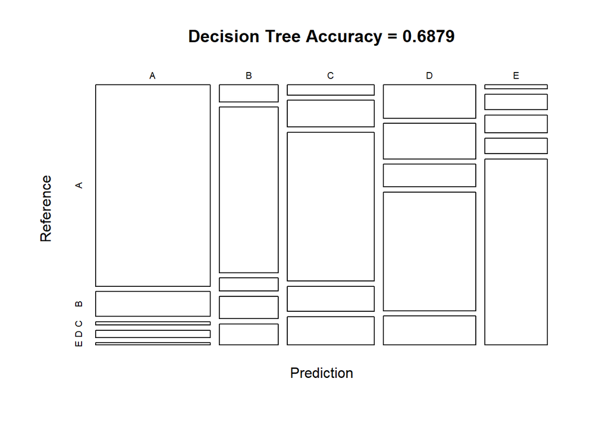

```r
plot(conMatxTree$table, col = conMatxTree$byClass,
     main = paste("Decision Tree Accuracy =", round(conMatxTree$overall['Accuracy'], 4)))
```

We can see that the accuracy rate of the model is low, 0.6879 and the out-of-sample-error is about 0.3121.

# Random Forest

```r
controlRandFor <- trainControl(method="cv", number=3, verboseIter=FALSE)
modRF1 <- train(classe ~ ., data=trainDatTrain, method="rf", trControl=controlRandFor)
modRF1$finalModel
```

```
##
## Call:
##  randomForest(x = x, y = y, mtry = param$mtry)
##                Type of random forest: classification
##                      Number of trees: 500
## No. of variables tried at each split: 27
##
##         OOB estimate of  error rate: 0.58%
## Confusion matrix:
##      A    B    C    D    E class.error
## A 3901    3    1    0    1 0.001280082
## B   21 2631    5    1    0 0.010158014
## C    0   10 2380    6    0 0.006677796
## D    0    0   19 2232    1 0.008880995
## E    0    1    3    7 2514 0.004356436
```

We then use the test data to validate the model looking at the Accuracy variable

```r
predictRF1 <- predict(modRF1, newdata=trainDatTest)
cmrf <- confusionMatrix(predictRF1, trainDatTest$classe)
cmrf
```

```
## Confusion Matrix and Statistics
##
##           Reference
## Prediction    A    B    C    D    E
##          A 1674   12    0    0    0
##          B    0 1126    5    1    1
##          C    0    1 1017    5    2
##          D    0    0    4  957    4
##          E    0    0    0    1 1075
##
## Overall Statistics
##
##                Accuracy : 0.9939
##                  95% CI : (0.9915, 0.9957)
##     No Information Rate : 0.2845
##     P-Value [Acc > NIR] : < 2.2e-16
##
##                   Kappa : 0.9923
##  Mcnemar's Test P-Value : NA
##
## Statistics by Class:
##
##                      Class: A Class: B Class: C Class: D Class: E
## Sensitivity            1.0000   0.9886   0.9912   0.9927   0.9935
## Specificity            0.9972   0.9985   0.9984   0.9984   0.9998
## Pos Pred Value         0.9929   0.9938   0.9922   0.9917   0.9991
## Neg Pred Value         1.0000   0.9973   0.9981   0.9986   0.9985
## Prevalence             0.2845   0.1935   0.1743   0.1638   0.1839
## Detection Rate         0.2845   0.1913   0.1728   0.1626   0.1827
## Detection Prevalence   0.2865   0.1925   0.1742   0.1640   0.1828
## Balanced Accuracy      0.9986   0.9936   0.9948   0.9956   0.9967
```

The accuracy of the random forest is very high, .9939 and the out-of-sample-error is .0061. This could be due to the accuracy of the model, but also to over fitting of the data.

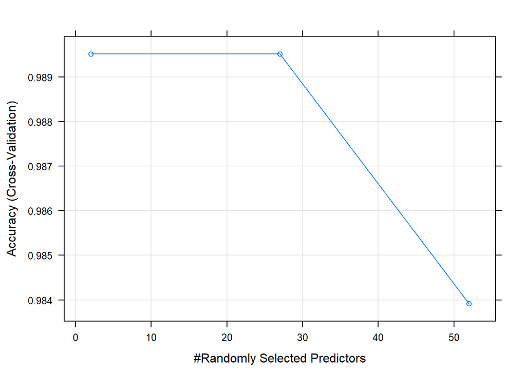

```r
plot(modRF1)
```

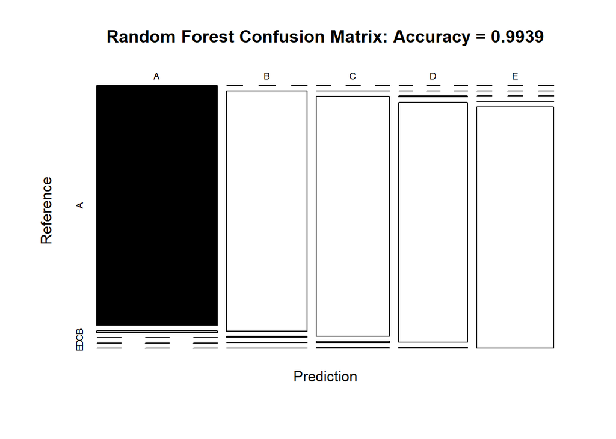

```r
plot(cmrf$table, col = cmrf$byClass, main = paste("Random Forest Confusion Matrix: Accuracy =", round(cmrf$overall['Accuracy'], 4)))
```

# Prediction with Generalized Boosted Regression Models

```r
set.seed(1234)
controlGBM <- trainControl(method = "repeatedcv", number = 5, repeats = 1)
modGBM  <- train(classe ~ ., data=trainDatTrain, method = "gbm", trControl = controlGBM, verbose = FALSE)
modGBM$finalModel
```

```
## A gradient boosted model with multinomial loss function.
## 150 iterations were performed.
## There were 52 predictors of which 44 had non-zero influence.
```

```r
print(modGBM)
```

```
## Stochastic Gradient Boosting
##
## 13737 samples
##    52 predictor
##     5 classes: 'A', 'B', 'C', 'D', 'E'
##
## No pre-processing
## Resampling: Cross-Validated (5 fold, repeated 1 times)
## Summary of sample sizes: 10987, 10990, 10990, 10990, 10991
## Resampling results across tuning parameters:
##
##   interaction.depth  n.trees  Accuracy   Kappa
##   1                   50      0.7471063  0.6795306
##   1                  100      0.8156065  0.7666968
##   1                  150      0.8493841  0.8094105
##   2                   50      0.8531706  0.8140224
##   2                  100      0.9027449  0.8769197
##   2                  150      0.9309906  0.9126685
##   3                   50      0.8943008  0.8661951
##   3                  100      0.9413273  0.9257507
##   3                  150      0.9595987  0.9488878
##
## Tuning parameter 'shrinkage' was held constant at a value of 0.1
##
## Tuning parameter 'n.minobsinnode' was held constant at a value of 10
## Accuracy was used to select the optimal model using  the largest value.
## The final values used for the model were n.trees = 150,
##  interaction.depth = 3, shrinkage = 0.1 and n.minobsinnode = 10.
```

Validate GBM

```r
predictGBM <- predict(modGBM, newdata=trainDatTest)
cmGBM <- confusionMatrix(predictGBM, trainDatTest$classe)
cmGBM
```

```
## Confusion Matrix and Statistics
##
##           Reference
## Prediction    A    B    C    D    E
##          A 1652   48    0    0    0
##          B   15 1060   34    8   11
##          C    4   31  981   19   11
##          D    3    0   10  929   14
##          E    0    0    1    8 1046
##
## Overall Statistics
##
##                Accuracy : 0.9631
##                  95% CI : (0.958, 0.9678)
##     No Information Rate : 0.2845
##     P-Value [Acc > NIR] : < 2.2e-16
##
##                   Kappa : 0.9533
##  Mcnemar's Test P-Value : NA
##
## Statistics by Class:
##
##                      Class: A Class: B Class: C Class: D Class: E
## Sensitivity            0.9869   0.9306   0.9561   0.9637   0.9667
## Specificity            0.9886   0.9857   0.9866   0.9945   0.9981
## Pos Pred Value         0.9718   0.9397   0.9379   0.9718   0.9915
## Neg Pred Value         0.9947   0.9834   0.9907   0.9929   0.9925
## Prevalence             0.2845   0.1935   0.1743   0.1638   0.1839
## Detection Rate         0.2807   0.1801   0.1667   0.1579   0.1777
## Detection Prevalence   0.2889   0.1917   0.1777   0.1624   0.1793
## Balanced Accuracy      0.9877   0.9582   0.9714   0.9791   0.9824
```

# Applying Best Model to Validation Data

Looking at the accuracies of the three models, it is clear the the ‘Random Forest’ model is the best fit. So will use it on the validation data

```r
Results <- predict(modRF1, newdata=testDatClean)
Results
```

```
##  [1] B A B A A E D B A A B C B A E E A B B B
## Levels: A B C D E
```